# Search for loci impactful to the %expanded phenotype

Part 3 - per gene summaries of variant impacts

23 February 2022

```r
    # options
    knitr::opts_chunk$set(echo = TRUE)
    options(stringsAsFactors = FALSE, dplyr.summarise.inform = FALSE)

    # libraries
    library(tidyverse)
    library(cowplot)
    library(fs)
    library(qtl2)
    library(ggbeeswarm)
    library(ggforce)
    library(flextable)
    library(ggrepel)
    devtools::load_all('../BXDstrs_package/BXDstrs')
    library(DT)
    library(ggh4x)

    # directory for production plots
    plot_dir = '../finalized_figs'; dir_create(plot_dir)
```

# 1 Load data

1. Output of `5_vep_annot_prep_data.R`
2. Precomputed eQTL mapping data data for list of top eQTL genes

```r
    vep_data = readRDS('../data/analysis_cache/annot/vep_data.rds')
    tx_info                  = vep_data$tx_info
    redux_vep_annot          = vep_data$redux_vep_annot
    assoc_test               = vep_data$assoc_test
    conseq_split             = vep_data$conseq_split
    redux_vep_annot_tab_disp = vep_data$redux_vep_annot_tab_disp
    loci_gts                 = vep_data$loci_gts
    al_freq                  = vep_data$al_freq
    raw_vep_annot            = vep_data$raw_vep_annot

    # get gene info
    gene_info = readRDS('../data/analysis_cache/embl_genes.rds')

    # NOTE: 020222 - variant analysis preceeds eQTL analysis, so no need to focus on top eQTL genes specificially
    # precomputed data from fig3 with top eQTL genes
    # eqtl_data = readRDS('../data/analysis_cache/eqtl_data.rds')

    # load cache file
    final_res = readRDS('../data/analysis_cache/bxd_qtl_scans/final_qtl.rds')

    # founder genotypes at max LOD marker for %expanded
    fou_gt_at_peak = maxmarg(BXDstrs::qtl_data$snp_probs[,'13'], minprob = 0.5) %>%
        .[[1]] %>%
        as.data.frame %>%
        rownames_to_column(var = 'strain') %>%
        pivot_longer(cols = !strain, names_to = 'marker', values_to = 'fou_gt') %>%
        semi_join(final_res$qtl_res %>%
                filter(metric == '% expanded') %>%
                unite('marker', c('chr', 'pos', 'end')) %>%
                slice_max(LOD, n = 1), by = 'marker') %>%
        mutate(fou_gt = recode(fou_gt, `1` = 'B', `2` = 'D'),
               fou_gt = replace_na(fou_gt, 'miss'))

    # isolate %expanded phenotype by strain
    prop_expand = final_res$pheno_vals %>%
        filter(metric == 'proportion_expanded') %>%
        left_join(strain_info %>%
              mutate(off_epoch = recode(off_epoch, epoch_1b = 'epoch_1a', epoch_1c = 'epoch_1a')) %>%
              select(strain = bxd_id, off_epoch), by = 'strain') %>%
        rename(perc_expand = pheno) %>%
        left_join(fou_gt_at_peak %>% select(!marker), by = 'strain')

    # create a function for reducing for plotting data
    reduce_for_plt = function(data) {
        data %>%
            left_join(conseq_split, by = 'Consequence') %>%
            arrange(severity) %>%
            distinct(loc_type, loc_id, SYMBOL, Feature, IMPACT, .keep_all = TRUE) %>%
            arrange(IMPACT) %>%
            distinct(loc_type, loc_id, SYMBOL, Feature, .keep_all = TRUE) %>%
            distinct(loc_type, loc_id, SYMBOL, .keep_all = TRUE)
    }
```

# 2 Load %expanded phenotype

```r
    in_cache_dir = '../data/analysis_cache/bxd_qtl_scans'
    pheno_vals = readRDS(path(in_cache_dir, 'final_qtl.rds'))$pheno_vals %>%
        filter(metric == 'proportion_expanded')
```

# 3 Data filters

These are the filters that are used at various points on variant/feature pairs. Also define filter thresholds here.

1. `filter1`: variants overlapping protein coding genes
2. `filter2`: variants segregating

```r
    # desel_conseq = c('intron_variant', 'intron_variant,non_coding_transcript_variant', 'intron_variant,NMD_transcript_variant')
    lod_thresh = -log10(0.0005)
    nonmaj_af_thresh = 0.15
```

# 4 Genes related to DNA repair

```r
    dna_repair_genes = c('Xrcc4', 'Ssbp2', 'Msh3', 'Ccnh', 'Atg10')
```

# 5 Useful reference

1. https://m.ensembl.org/info/genome/variation/prediction/protein_function.html

# 6 Variants by genomic coordinate

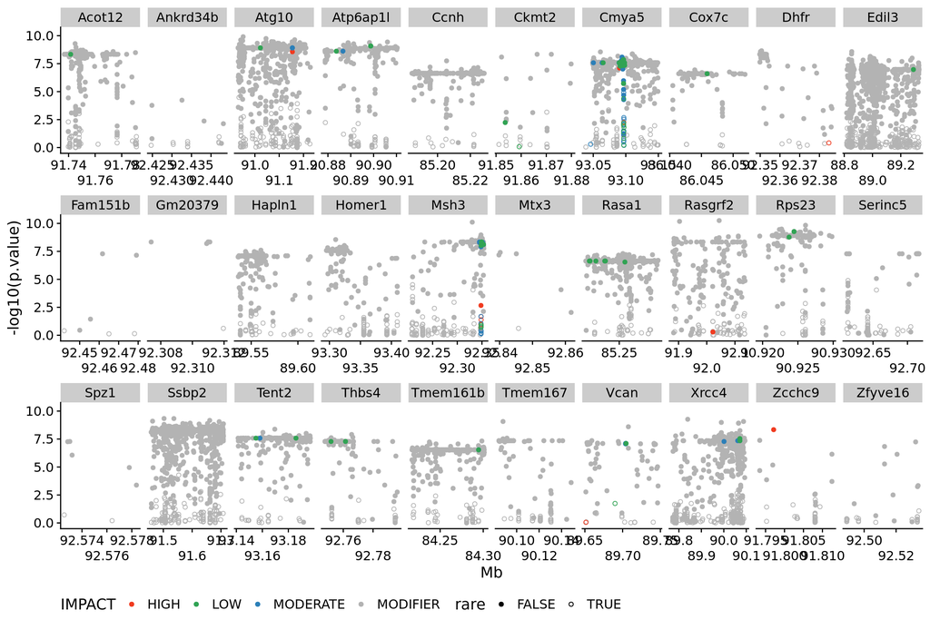

```r
    # top_genes = eqtl_data$gene_ord %>%
    #   filter(Rank != '>10' | gene_name %in% dna_repair_genes) %>%
    #   pull(gene_name)
    top_genes_data = redux_vep_annot %>%
        # old filter
        # filter(IMPACT %in% c('HIGH', 'MODERATE', 'LOW') |
        #      ( IMPACT == 'MODIFIER' & (!Consequence %in% desel_conseq) )) %>%
        reduce_for_plt %>%
        # arrange(IMPACT) %>%
        # distinct(loc_type, loc_id, SYMBOL, .keep_all = TRUE) %>%
        left_join(assoc_test, by = c('loc_type', 'loc_id')) %>%
        filter(!is.na(p.value)) %>%
        mutate(pass_filter = -log10(p.value) >= lod_thresh & nonmaj_af >= nonmaj_af_thresh) %>%
        mutate(rare = nonmaj_af < nonmaj_af_thresh) # %>%
        # filter(SYMBOL %in% top_genes)

    p = top_genes_data %>%
        ggplot(aes(pos/1e6, -log10(p.value), color = IMPACT, shape = rare)) +
        geom_point(data = ~.x %>% filter(IMPACT == 'MODIFIER')) + # make sure the MODIFIER points are underneath the other effects
        geom_point(data = ~.x %>% filter(IMPACT != 'MODIFIER')) +
        scale_color_manual(values = c('HIGH' = '#f03b20', 'MODERATE' = '#2c7fb8' , 'LOW' = '#31a354', 'MODIFIER' = 'gray70')) +
        scale_shape_manual(values = c(`TRUE` = 1, `FALSE` = 19)) +
        scale_x_continuous(breaks = scales::breaks_pretty(n = 3),
                   guide = guide_axis(n.dodge = 2)) +
        facet_wrap(~SYMBOL, scale = 'free_x', nrow = 3) +
        theme_half_open() +
        theme(legend.position = 'bottom') +
        labs(x = 'Mb')
    p
```

```r
    ggsave('test.pdf', p, w = 12, h = 8)
```

# 7 Functions for plotting and table summary

```r
    # function for plotting a variant impact view for a single gene
    variant_combo_plot = function(to_plt, gene, xlims = NULL, impacts = c('HIGH', 'MODERATE', 'LOW', 'MODIFIER'), label_locus = FALSE, loc_types = c('str', 'snp', 'sv'), plt_title = '') {
        if (is.null(xlims)) {
            xlims = tx_info %>% filter(gene_name == gene) %>% summarise(xlims = c(min(tx_pos), max(tx_end))) %>% pull(xlims)
        }
        p1 = tx_info %>%
            filter(gene_name == gene) %>%
            arrange(tx_type) %>%
            mutate(tx_id = fct_inorder(tx_id)) %>%
            ggplot() +
            geom_tile(data = ~.x %>% distinct(tx_id, exon_pos, exon_end),
                  aes(width = (exon_end - exon_pos), y = tx_id, x = (exon_pos + exon_end)/2), height = 0.9, fill = NA, color = 'black') +
            geom_tile(data = ~.x %>% distinct(tx_id, cds_pos, cds_end) %>% filter(!is.na(cds_pos)),
                  aes(width = (cds_end - cds_pos), y = tx_id, x = (cds_pos + cds_end)/2), height = 0.9) +
            geom_tile(data = ~.x %>% distinct(tx_id, tx_pos, tx_end, tx_type),
                  aes(width = (tx_end - tx_pos), y = tx_id, x = (tx_pos + tx_end)/2, fill = tx_type), height = 0.1) +
            coord_cartesian(xlim = xlims) +
            scale_fill_brewer(palette = 'Dark2') +
            theme_half_open() +
            theme(
                legend.position = 'none',
                axis.title.y = element_blank(),
                plot.title = element_text(size = 6, hjust = 0.5)) %>%
            labs(x = 'pos', title = plt_title)
        p2 = to_plt %>%
            filter(loc_type %in% loc_types) %>%
            filter(SYMBOL == gene) %>%
            filter(IMPACT %in% impacts) %>%
            ggplot(aes(pos/1e6, -log10(p.value), color = IMPACT, shape = rare)) +
            geom_point(data = ~.x %>% filter(IMPACT == 'MODIFIER')) + # make sure the MODIFIER points are underneath the other effects
            geom_point(data = ~.x %>% filter(IMPACT != 'MODIFIER')) +
            scale_color_manual(values = c('HIGH' = '#f03b20', 'MODERATE' = '#2c7fb8' , 'LOW' = '#31a354', 'MODIFIER' = 'gray70')) +
            scale_shape_manual(values = c(`TRUE` = 1, `FALSE` = 19)) +
            coord_cartesian(xlim = xlims) +
            theme_half_open() +
            theme(legend.position = 'bottom') %>%
            labs(x = 'Mb')
        if (label_locus) {
            p2 = p2 + geom_text_repel(aes(label = locus), max.overlaps = Inf, min.segment.length = 0)
        }
        p = plot_grid(p1, p2, ncol = 1, axis = 'lr', align = 'v')
        p
    }

    # function to pull data from raw VEP output which is not reduced at all and has all the useful columns like rsid and SIFT
    smry_var_tbl = function(data) {
        raw_vep_annot %>%
            semi_join(data) %>% # data can be whatever you want as long as columns are named the same for join to work
            # glimpse
            select(loc_type, loc_id, SYMBOL, IMPACT, Feature, Consequence, BIOTYPE, Existing_variation, Allele, Amino_acids, SIFT) %>%
            left_join(conseq_split %>% select(Consequence, top_csq), by = 'Consequence')
    }
```

# 8 Xrcc4

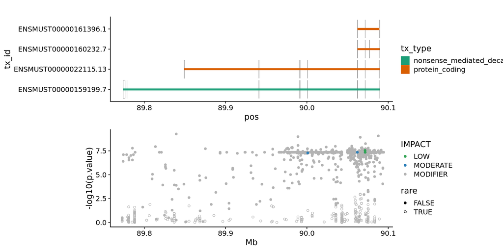

```r
    p = variant_combo_plot(top_genes_data, 'Xrcc4')
    # p2 = variant_combo_plot(top_genes_data, 'Xrcc4', loc_types = c('str', 'snp'))
    # p = plot_grid(p1, p2, nrow = 1)
    p
```

```r
    ggsave('test.pdf', p, w = 18, h = 5)

    # possible loci of interest
    # loc_of_int = c('chr13_89991771_89996960', 'chr13_90001025_90001025', 'chr13_90062046_90062046', 'chr13_90071534_90071534', 'chr13_90071601_90071601', 'chr13_90071653_90071653')
    # smry_var_tbl(redux_vep_annot_tab_disp, loc_of_int)
```

1. Splice region variant might really be low impact since it is 5 base-paris downstream of the consensus GU splice donor sequence (Xrcc4 is transcribed right to left)

```r
    redux_vep_annot %>%
        filter(SYMBOL == 'Xrcc4') %>%
        filter(IMPACT %in% c('HIGH', 'MODERATE', 'LOW')) %>%
        filter(Feature == 'ENSMUST00000022115') %>%
        select(loc_id, SYMBOL, Feature) %>%
        smry_var_tbl %>%
        arrange(Consequence)
```

| loc_type | loc_id | SYMBOL | IMPACT | Feature | Consequence | BIOTYPE | Existing_variation | Allele | Amino_acids | SIFT | top_csq |
| --- | --- | --- | --- | --- | --- | --- | --- | --- | --- | --- | --- |
| snp | chr13_90001025_90001025 | Xrcc4 | MODERATE | ENSMUST00000022115 | missense_variant | protein_coding | rs13461242 | T | D/E | tolerated(1) | missense_variant |
| snp | chr13_90062046_90062046 | Xrcc4 | MODERATE | ENSMUST00000022115 | missense_variant | protein_coding | rs13461241 | T | R/Q | tolerated(0.48) | missense_variant |
| snp | chr13_90071601_90071601 | Xrcc4 | MODERATE | ENSMUST00000022115 | missense_variant | protein_coding | rs49037766 | C | T/A | tolerated(0.1) | missense_variant |
| snp | chr13_90071534_90071534 | Xrcc4 | LOW | ENSMUST00000022115 | splice_region_variant,intron_variant | protein_coding | rs51454619 | A | - | - | splice_region_variant |
| snp | chr13_90071653_90071653 | Xrcc4 | LOW | ENSMUST00000022115 | synonymous_variant | protein_coding | rs50305310 | G | Y | - | synonymous_variant |

# 9 Atg10

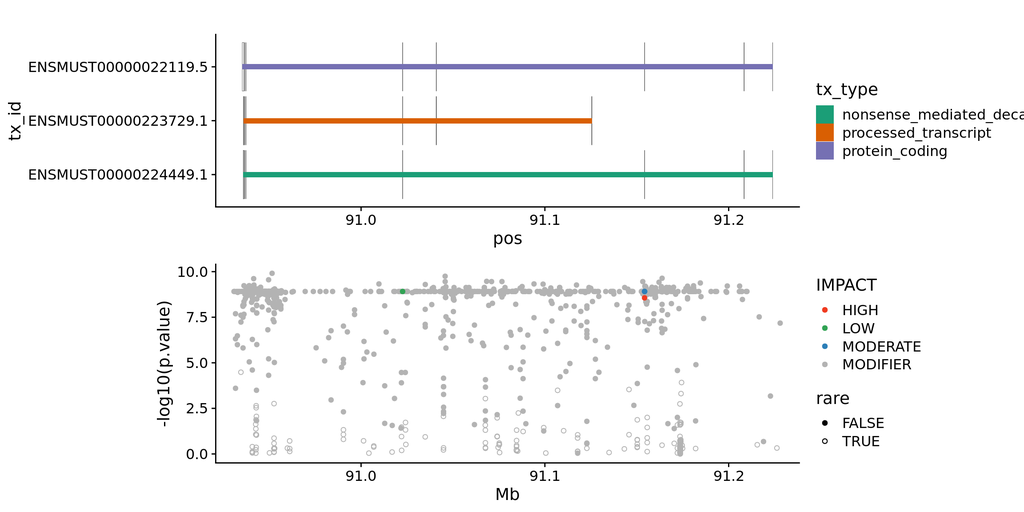

```r
    p = variant_combo_plot(top_genes_data, 'Atg10')
    # p2 = variant_combo_plot(top_genes_data, 'Atg10', loc_types = c('str', 'snp'), plt_title = 'strs+snps')
    # p = plot_grid(p1, p2, nrow = 1)
    p
```

```r
    ggsave('test.pdf', p, w = 18, h = 5)
```

```r
    redux_vep_annot %>%
        filter(SYMBOL == 'Atg10') %>%
        filter(IMPACT %in% c('HIGH', 'MODERATE', 'LOW')) %>%
        filter(Feature == 'ENSMUST00000022119') %>%
        select(loc_id, SYMBOL, Feature) %>%
        smry_var_tbl %>%
        arrange(Consequence)
```

| loc_type | loc_id | SYMBOL | IMPACT | Feature | Consequence | BIOTYPE | Existing_variation | Allele | Amino_acids | SIFT | top_csq |
| --- | --- | --- | --- | --- | --- | --- | --- | --- | --- | --- | --- |
| snp | chr13_91154245_91154245 | Atg10 | HIGH | ENSMUST00000022119 | frameshift_variant | protein_coding | - | CAGGTGTTCCCACATGTGGGAACACCTGCCAGTGTGCTCA | A/VSTLAGVPTCGNTCX | - | frameshift_variant |
| snp | chr13_91154245_91154245 | Atg10 | MODERATE | ENSMUST00000022119 | inframe_insertion | protein_coding | rs230013535 | CAGGTGTTCCCA | A/VGTPA | - | inframe_insertion |
| snp | chr13_91154257_91154257 | Atg10 | MODERATE | ENSMUST00000022119 | missense_variant | protein_coding | rs30292539 | G | L/S | tolerated(0.78) | missense_variant |
| snp | chr13_91154261_91154261 | Atg10 | MODERATE | ENSMUST00000022119 | missense_variant | protein_coding | rs247872711 | C | T/A | tolerated(0.33) | missense_variant |
| snp | chr13_91022608_91022608 | Atg10 | LOW | ENSMUST00000022119 | synonymous_variant | protein_coding | rs29511431 | G | R | - | synonymous_variant |

## 9.1 Confidence in rs230013535

1. Pull per strain metrics for the chr13:91154245-91154245 locus
2. `dp`: Approximate read depth (reads with MQ=255 or with bad mates are filtered)
3. `gq`: Genotype Quality
4. `ad`: Allelic depths for the ref and alt alleles in the order listed

Observations:

```r
    qual = tibble(locus = 'chr13_91154245_91154245') %>%
        separate('locus', c('chr', 'pos', 'end'), remove = FALSE) %>%
        rowwise %>%
        mutate(data = map(sprintf('%s:%s-%s', chr, pos, end), function(.x) {
            cmd = sprintf("bcftools query -f '[%%CHROM\t%%POS\t%%END\t%%REF\t%%ALT\t%%SAMPLE\t%%GT\t%%AD\t%%DP\t%%GQ\n]' %s -r %s",
                          '../data/vep_annot/bxd_snp_indel.annot.vcf.gz',
                          .x)
            read_tsv(pipe(cmd),
                     col_names = c('chr', 'pos', 'end', 'ref', 'alt', 'short_name', 'gt', 'ad', 'dp', 'gq'),
                     col_types = cols(pos = 'i', end = 'i', .default = 'c'))
        })) %>%
        select(locus, data) %>% unnest(data)
```

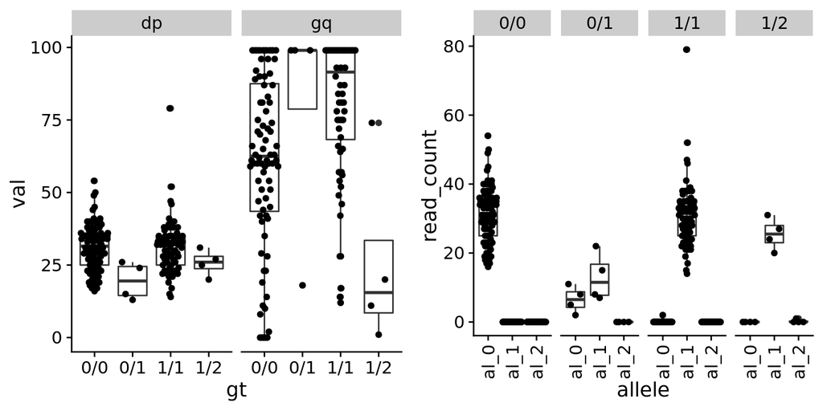

```r
    p1 = qual %>%
        mutate(across(c(dp, gq), as.numeric)) %>%
        # group_by(gt) %>%
        # skimr::skim(ad, dp, gq) %>%
        pivot_longer(cols = c(dp, gq), names_to = 'var', values_to = 'val') %>%
        ggplot(aes(gt, val)) +
        geom_boxplot() +
        geom_quasirandom() +
        facet_wrap(~var, nrow = 1) +
        theme_half_open()
    p2 = qual %>%
        select(gt, ad) %>%
        # filter(gt == '1/2')
        separate('ad', str_c('al_', 0:2), sep = ',', convert = TRUE) %>%
        pivot_longer(cols = matches('al_'), names_to = 'allele', values_to = 'read_count') %>%
        ggplot(aes(allele, read_count)) +
        geom_boxplot() +
        geom_quasirandom() +
        facet_wrap(~gt, nrow = 1) +
        theme_half_open() +
        theme(axis.text.x = element_text(angle = 90, hjust = 1, vjust = 0.5))
    p = plot_grid(p1, p2, nrow = 1)
    p
```

```r
    ggsave('test.pdf', p, w = 8, h = 4)
```

# 10 Msh3

1. Cluster of variants within 5’ end of gene
2. High impact SVs need to be evaluated manually

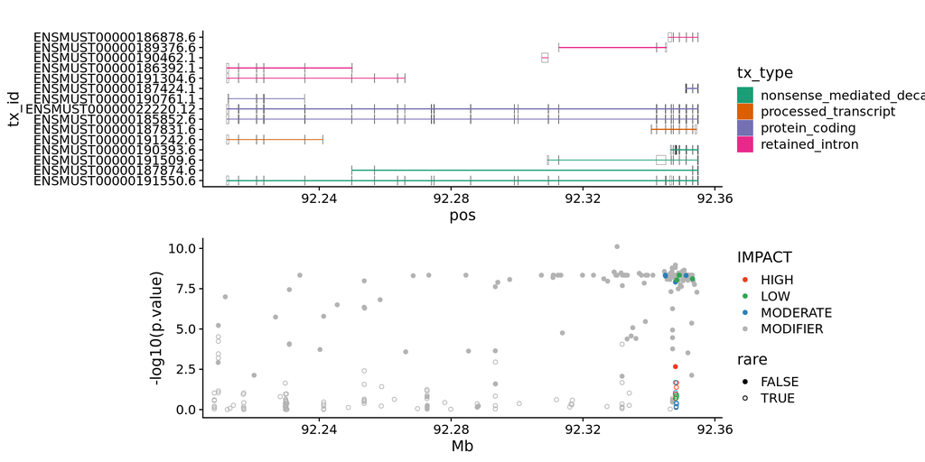

```r
    p = variant_combo_plot(top_genes_data, 'Msh3')
    # p2 = variant_combo_plot(top_genes_data, 'Msh3', loc_types = c('str', 'snp'), plt_title = 'strs+snps')
    # p = plot_grid(p1, p2, nrow = 1)
    p
```

```r
    ggsave('test.pdf', p, w = 18, h = 5)

    # possible loci of interest
    # loc_of_int = c('chr13_92253653_92258474')
    # smry_var_tbl(redux_vep_annot_tab_disp, loc_of_int)
```

# 11 Msh3 5’

1. A couple of missense variants not likely relevant around 92.344
2. Cluster of variants coinciding with LTR and large exon of short transcript of Msh3
3. HIGH impact below LOD5 is artifact of calling within SV

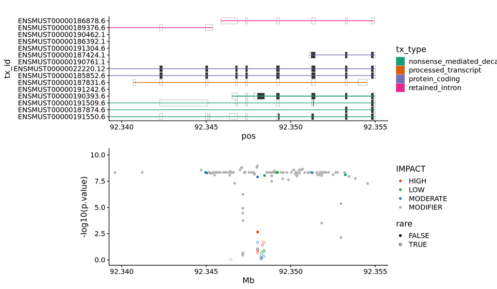

```r
    p = variant_combo_plot(top_genes_data, 'Msh3', xlims = c(92.34, 92.355))
    p
```

```r
    ggsave('test.pdf', p, w = 12, h = 7)
```

## 11.1 Transcripts

1. No difference between mm9 and mm10 annotations on EMBL
2. UCSC shows only `ENSMUST00000185852`, `ENSMUST00000022220` and `ENSMUST00000187424`
3. EMBL has an extra short `ENSMUST00000190761` at C-terminus not annotated in UCSC
4. Transcripts:
   - `ENSMUST00000185852`: longest full length
   - `ENSMUST00000022220`: nearly full length almost identical is 1 fewer aa
   - `ENSMUST00000187424`: short N-terminal transcript
   - `ENSMUST00000190393`: short N-terminal “Nonsense mediated decay” with longer exon

```r
    redux_vep_annot %>%
        filter(SYMBOL == 'Msh3') %>%
        filter(IMPACT %in% c('HIGH', 'MODERATE', 'LOW')) %>%
        distinct(loc_type, loc_id, Feature, BIOTYPE) %>%
        count(Feature, BIOTYPE, name = 'n_var') %>%
        arrange(BIOTYPE)
```

| Feature | BIOTYPE | n_var |
| --- | --- | --- |
| ENSMUST00000187874 | nonsense_mediated_decay | 2 |
| ENSMUST00000190393 | nonsense_mediated_decay | 25 |
| ENSMUST00000191550 | nonsense_mediated_decay | 3 |
| ENSMUST00000187831 | processed_transcript | 1 |
| ENSMUST00000022220 | protein_coding | 8 |
| ENSMUST00000185852 | protein_coding | 8 |
| ENSMUST00000187424 | protein_coding | 3 |
| ENSMUST00000186878 | retained_intron | 1 |

## 11.2 Variants that meet thresholds

1. Reference for total number of variants

```r
    loc_ids = redux_vep_annot %>%
        left_join(assoc_test %>% select(loc_type, loc_id, p.value, nonmaj_af), by = c('loc_type', 'loc_id')) %>%
        mutate(LOD = -log10(p.value)) %>%
        filter(nonmaj_af >= nonmaj_af_thresh, LOD >= lod_thresh) %>%
        filter(SYMBOL == 'Msh3') %>%
        filter(IMPACT %in% c('HIGH', 'MODERATE', 'LOW')) %>%
        arrange(pos) %>%
        distinct(loc_type, loc_id, nonmaj_af, LOD)
    loc_ids
```

| loc_type | loc_id | nonmaj_af | LOD |
| --- | --- | --- | --- |
| snp | chr13_92344961_92344961 | 0.4383117 | 8.338067 |
| snp | chr13_92345041_92345041 | 0.4350649 | 8.286252 |
| sv | chr13_92348038_92348424_DEL | 0.4230769 | 7.909981 |
| snp | chr13_92348451_92348451 | 0.4133333 | 8.041381 |
| snp | chr13_92348452_92348452 | 0.4133333 | 8.041381 |
| snp | chr13_92349155_92349155 | 0.4383117 | 8.338067 |
| snp | chr13_92349194_92349194 | 0.4383117 | 8.338067 |
| snp | chr13_92349232_92349232 | 0.4383117 | 8.338067 |
| snp | chr13_92351271_92351271 | 0.4350649 | 8.317942 |
| snp | chr13_92353222_92353222 | 0.4350649 | 8.114742 |

[output cut: 1 more lines]

## 11.3 Effect smry: variants in protein coding txs

```r
    var_smry = redux_vep_annot %>%
        filter(SYMBOL == 'Msh3') %>%
        semi_join(loc_ids, by = 'loc_id') %>%
        select(loc_id, SYMBOL, Feature) %>%
        smry_var_tbl %>%
        filter(IMPACT %in% c('HIGH', 'MODERATE', 'LOW')) %>%
        select(!c(SYMBOL, Allele)) %>%
        arrange(loc_id) %>%
        select(loc_type, loc_id, IMPACT, Consequence, Feature, BIOTYPE, Existing_variation, Amino_acids, SIFT)
    prot_code = var_smry %>%
        filter(BIOTYPE == 'protein_coding')
    ft = prot_code %>%
        flextable %>%
        merge_v(j = 1:9) %>%
        theme_box
    ft
```

[output not shown]

```r
    # save_as_html(ft, path = 'test.html')
```

## 11.4 Effect smry: variants only in non-protein coding txs

1. If a variant has an effect in a protein coding transcript, we need not consider its effect in non-coding transcripts

```r
    ft = var_smry %>%
        anti_join(prot_code, by = 'loc_id') %>%
        flextable %>%
        merge_v(j = 1:9) %>%
        theme_box
    ft
```

| loc_type | loc_id | IMPACT | Consequence | Feature | BIOTYPE | Existing_variation | Amino_acids | SIFT |
| --- | --- | --- | --- | --- | --- | --- | --- | --- |
| sv | chr13_92348038_92348424_DEL | MODERATE | inframe_deletion,NMD_transcript_variant,feature_truncation | ENSMUST00000190393 | nonsense_mediated_decay | - | - | - |
| snp | chr13_92348451_92348451 | LOW | splice_region_variant,intron_variant,NMD_transcript_variant |  |  | rs49933543 |  |  |
|  | chr13_92348452_92348452 |  |  |  |  | rs48930870 |  |  |

```r
    # save_as_html(ft, path = 'test.html')
```

# 12 Ccnh

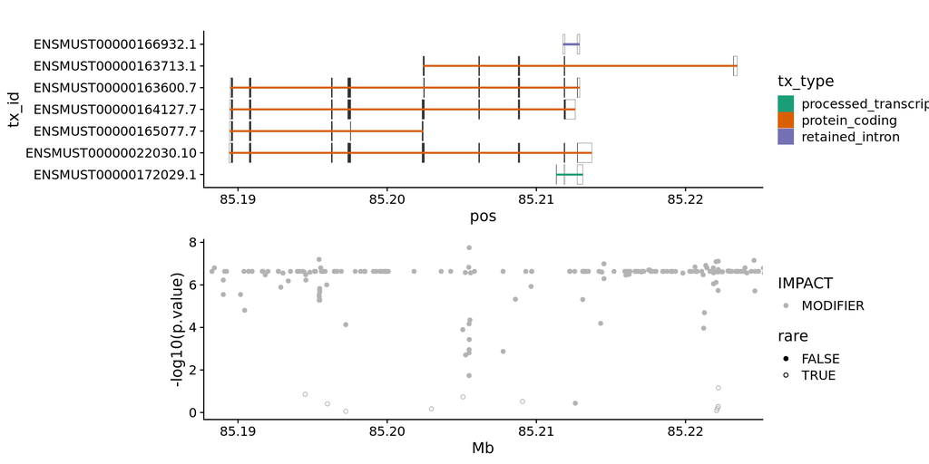

```r
    p = variant_combo_plot(top_genes_data, 'Ccnh')
    # p2 = variant_combo_plot(top_genes_data, 'Ccnh', loc_types = c('str', 'snp'), plt_title = 'strs+snps')
    # p = plot_grid(p1, p2, nrow = 1)
    p
```

```r
    ggsave('test.pdf', p, w = 18, h = 5)
```

# 13 Ssbp2

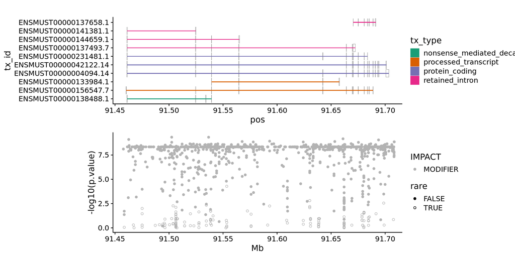

```r
    p = variant_combo_plot(top_genes_data, 'Ssbp2')
    # p2 = variant_combo_plot(top_genes_data, 'Ssbp2', loc_types = c('str', 'snp'), plt_title = 'strs+snps')
    # p = plot_grid(p1, p2, nrow = 1)
    p
```

```r
    ggsave('test.pdf', p, w = 18, h = 5)

    # possible loci of interest
    # loc_of_int = c('chr13_91647553_91658316')
    # smry_var_tbl(redux_vep_annot_tab_disp, loc_of_int)
```

# 14 Detailed Supplementary Table IMPACTFUL VARS

```r
    tx_labels = tribble(~Feature, ~feat_lab,
        'ENSMUST00000022115', 'Xrcc4-201',
        'ENSMUST00000022119', 'Atg10-201',
        'ENSMUST00000185852', 'Msh3-202',
        # 'ENSMUST00000187424', 'Msh3-205',
        'ENSMUST00000190393', 'Msh3-209'
    )
    smry =
        redux_vep_annot %>%
        left_join(assoc_test %>% select(loc_type, loc_id, p.value, nonmaj_af), by = c('loc_type', 'loc_id')) %>%
        mutate(LOD = -log10(p.value)) %>%
        filter(nonmaj_af >= nonmaj_af_thresh, LOD >= lod_thresh) %>%
        select(loc_id, SYMBOL, Feature) %>%
        smry_var_tbl %>%
        # aggregate SIFT scores across multiple transcripts
        mutate(SIFT = str_replace(SIFT, regex('\\(.*\\)$'), '')) %>%
        group_by(loc_id) %>%
        #
        mutate(SIFT = str_c(SIFT %>% discard(~.x == '-') %>% unique, collapse = '\n')) %>%
        ungroup %>%
        inner_join(tx_labels, by = 'Feature') %>%
        filter(IMPACT %in% c('HIGH', 'MODERATE', 'LOW')) %>%
        mutate(SYMBOL = fct_relevel(SYMBOL, c('Xrcc4', 'Atg10', 'Msh3'))) %>%
        arrange(SYMBOL, top_csq) %>%
        select(SYMBOL, "Locus type" = loc_type, Locus = loc_id, "Top consequence" = top_csq, IMPACT, Feature = feat_lab, BIOTYPE, Existing_variation, Amino_acids, SIFT)
```

```r
    # we only want to display variants for Msh3-209 that are not also variants in Msh3-202
    smry = rbind(
        smry %>% filter(!Feature %in% c('Msh3-202', 'Msh3-209')),
        smry %>%
            filter(Feature %in% c('Msh3-202', 'Msh3-209')) %>%
            # factorize in order to reorder
            mutate(Feature = fct_relevel(Feature, c('Msh3-202', 'Msh3-209'))) %>%
            arrange(Feature) %>%
            distinct(Locus, .keep_all = TRUE)
    )

    if (0) {
        fs = 8; padd = 2
        ws = ( smry %>% flextable %>% padding(padding = padd, part = "all") %>% fontsize(size = fs, j = 1:10) %>% merge_v(j = 1:10) %>% autofit %>% dim )$widths
        ft = smry %>%
            split(.$SYMBOL) %>%
            map(~.x %>% flextable %>%
                    merge_v(j = 1:10) %>%
                    fontsize(size = fs, j = 1:10) %>%
                    padding(padding = padd, part = "all") %>%
                    width(j = 1:10, width = as.numeric(ws)) %>%
                    theme_box)
        # ft$Xrcc4
        # ft$Atg10
        # ft$Msh3
        save_as_html(values = ft, path = 'test.html')
    }

    # as a single table
    ft = smry %>% flextable %>% merge_v(j = 1:10) %>% theme_box
    ft
```

[output not shown]

```r
    # save_as_html(ft, path = 'test.html')

    save_as_html(ft, path = path(plot_dir, 'Suppl_Tbl_2.html'))
```

# 15 Supplementary Fig MSH3 VARS

1. May not be needed if info moved to main figure 3

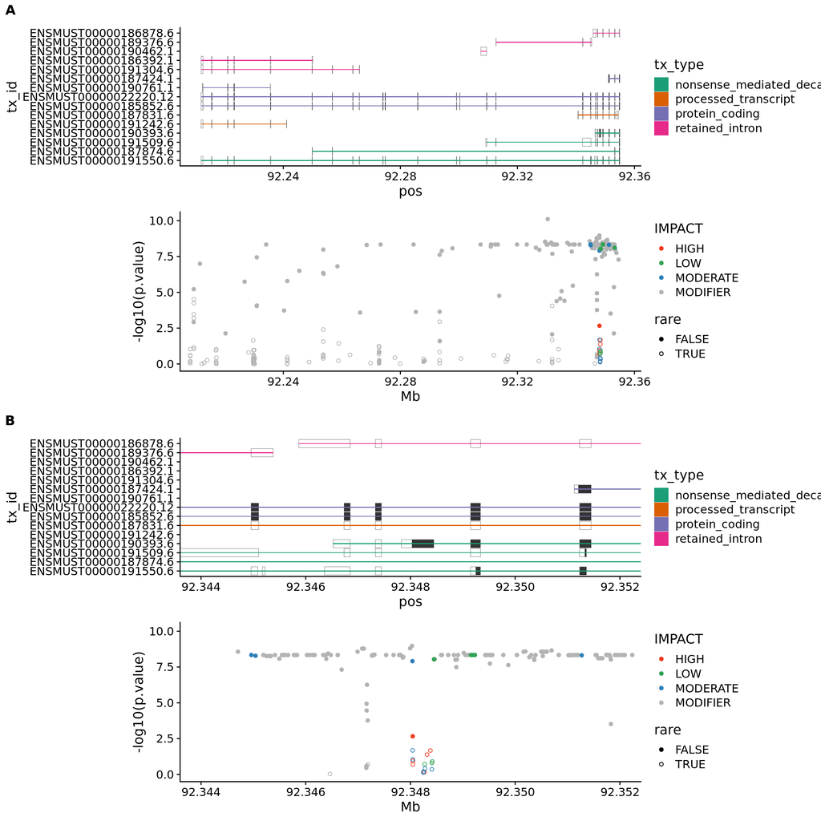

```r
    p1 = variant_combo_plot(top_genes_data, 'Msh3')
    p2 = variant_combo_plot(top_genes_data, 'Msh3', xlims = c(92.344, 92.352))
    p = plot_grid(p1, p2, nrow = 2, labels = c('A', 'B'))
    p
```

```r
    ggsave('test.pdf', p, w = 12, h = 12)

    # figure print
    ggsave(path(plot_dir, 'Suppl_Fig_7.pdf'), p, w = 12, h = 12)
```

# 16 Main figure 3

1. More decorated version of what used to be Supplementary Fig MSH3 VARS

## 16.1 Get CDS positions for protein coding transcript of Msh3

```r
    # connect to Ensembl
    e102 = biomaRt::useEnsembl(
        biomart = 'genes',
        host = 'http://nov2020.archive.ensembl.org',
        dataset = 'mmusculus_gene_ensembl',
        version = 102, verbose = FALSE)

    # get detailed info for ENSMUST00000185852.6
    attr_to_get = c(
        gene_id    = "ensembl_gene_id",
        tx_id      = "ensembl_transcript_id",
        cds_pos    = "cds_start",
        cds_end    = "cds_end",
        exon_id    = "ensembl_exon_id",
        rank       = "rank",
        genome_pos = "genomic_coding_start",
        genome_end = "genomic_coding_end"
    )
    msh3_main_tx = biomaRt::getBM(
        attributes = attr_to_get,
        filters = c('ensembl_transcript_id'),
        values = c(list('ENSMUST00000185852')),
        mart = e102) %>%
        as_tibble %>%
        rename(all_of(attr_to_get)) %>%
        arrange(rank)
```

```r
    # the genomic coordinates are really weird from EBML ... align pfams manually above
    # # determine genomic coordinates for pfam domains even if these are spllit
    # # approx(x = c(139, 256), y = c(92353225, 92353342), xout = c(188, 299), rule = 2, method = 'linear')$y
    # define pfam motif domain positions
    msh3_pfam = tribble(
        ~domain_name , ~cds_pos , ~cds_end  , ~type          , ~accession,
        'MutS_I'   , 188 , 299  , 'DNA mismatch binding' , 'PF01624' ,
        'MutS_II'  , 324 , 480  , 'connector'            , 'PF05188' ,
        'MutS_III' , 498 , 796  , 'lever'                , 'PF05192' ,
        'MutS_V'   , 850 , 1052 , 'ATPase'               , 'PF00488' ) %>%
        mutate(across(c(cds_pos, cds_end), ~.x*3))
    pfam_coors =
        crossing(
        msh3_main_tx %>%
            select(exon_id, rank, t_pos = cds_pos, t_end = cds_end, genome_pos, genome_end),
        msh3_pfam %>%
            select(type, domain_name, q_pos = cds_pos, q_end = cds_end)
        ) %>%
        filter((q_pos >= t_pos & q_pos <= t_end) |
               (q_end >= t_pos & q_end <= t_end) |
               (t_pos >= q_pos & t_pos <= q_end) |
               (t_end >= q_pos & t_end <= q_end)
           ) %>%
        arrange(domain_name, rank) %>%
        rowwise %>%
        mutate(q_genome = list(
            approx(x    = c_across(c(t_pos, t_end)),
                   y    = c_across(c(genome_end, genome_pos)), # NOTE: gene is reversed
                   # y    = c_across(c(genome_pos, genome_end)),
                   xout = c_across(c(q_pos, q_end)),
                   rule = 2, method = 'linear')$y
        )) %>%
        mutate(q_genome_pos = q_genome[2], q_genome_end = q_genome[1]) %>%
        select(!q_genome) %>%
        # mutate(check = (q_genome_end - q_genome_pos))
        select(domain_name, type, rank, cds_pos = q_pos, cds_end = q_end, genome_pos = q_genome_pos, genome_end = q_genome_end)

    # check
    # pfam_coors
    if (0) {
        pfam_coors %>%
            group_by(domain_name) %>%
            summarise(exons = str_c(rank, collapse = ','))
        pfam_coors %>%
            mutate(len = genome_end - genome_pos, tot_len = cds_end - cds_pos) %>%
            group_by(domain_name, tot_len) %>%
            summarise(check_len = sum(len))
        pfam_coors %>%
            group_by(domain_name) %>%
            summarise(pos = min(genome_pos), end = max(genome_end))
    }
```

## 16.2 QTL by position

1. Each variant has a -log10(p) score
2. Note that this is different from QTL mapping with rqtl2

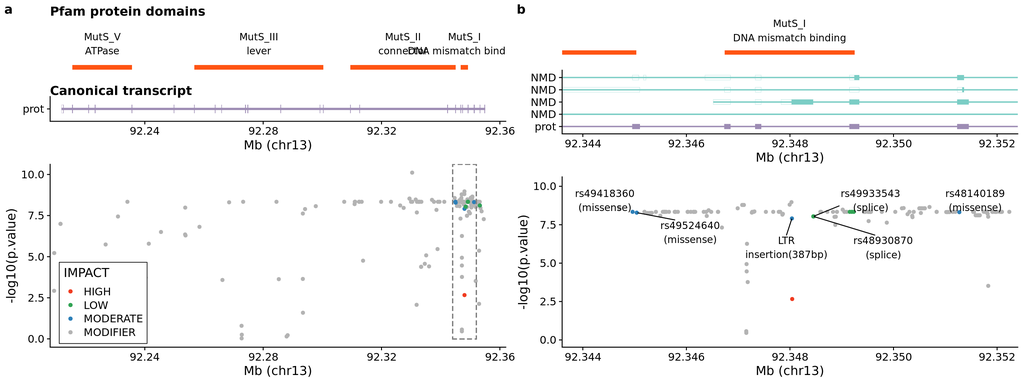

```r
    # configs
    # xlims = c(92.344, 92.352)
    xlims = c(92.215, 92.355)
    xlims_zoom = c(92.344, 92.352)
    nmd_txs = c('ENSMUST00000191550.6', 'ENSMUST00000190393.6',
                'ENSMUST00000191509.6', 'ENSMUST00000187874.6')
    prot_tx = 'ENSMUST00000185852.6'
    tx_cols = c(rep('#7BCDC5', length(nmd_txs)), rep('#9D8CB4', 1)) %>% set_names(c(nmd_txs, prot_tx))
    tx_labs = c(rep('NMD', length(nmd_txs)), rep('prot', 1)) %>% set_names(c(nmd_txs, prot_tx))

    # pfram track
    pfam_track = pfam_coors %>%
        group_by(domain_name, type) %>%
        summarise(genome_pos = min(genome_pos), genome_end = max(genome_end)) %>%
        ungroup %>%
        mutate(across(c(genome_pos, genome_end), ~.x/1e6)) %>%
        mutate(label = sprintf('%s\n%s', domain_name, type)) %>%
        ggplot() +
        theme_half_open() +
        theme(axis.title.y = element_blank(),
              axis.text.y  = element_blank(),
              axis.ticks.y = element_blank(),
              axis.line.y  = element_blank(),
              axis.title.x = element_blank(),
              axis.text.x  = element_blank(),
              axis.ticks.x = element_blank(),
              axis.line.x  = element_blank()
        )
    pfam_track1 = pfam_track +
        geom_tile(aes(width = (genome_end - genome_pos), y = 0, x = (genome_pos + genome_end)/2), fill = '#FF5413', height = 0.2) +
        geom_text(aes(label = label, x = (genome_end + genome_pos)/2, y = 1), hjust = 0.5)
    pfam_track2 = pfam_track +
        geom_tile(aes(width = (genome_end - genome_pos), y = 0, x = (genome_pos + genome_end)/2), fill = '#FF5413', height = 0.2) +
        geom_text(aes(label = label, x = (genome_end + genome_pos)/2, y = 1), hjust = 0.5)

    # transcripts tracks
    canon_tx = tx_info %>%
        filter(gene_name == 'Msh3') %>%
        filter(tx_id == prot_tx)
    NMD_tx = tx_info %>%
        filter(gene_name == 'Msh3') %>%
        filter(tx_id %in% c(nmd_txs, prot_tx))
    tx_track = canon_tx %>%
        ggplot() +
        # non-coding exon
        geom_tile(data = ~.x %>% distinct(tx_id, exon_pos, exon_end),
              aes(width = (exon_end - exon_pos), y = tx_id, x = (exon_pos + exon_end)/2, color = tx_id), height = 0.4, fill = NA) +
        # coding exon
        geom_tile(data = ~.x %>% distinct(tx_id, cds_pos, cds_end) %>% filter(!is.na(cds_pos)),
              aes(width = (cds_end - cds_pos), y = tx_id, x = (cds_pos + cds_end)/2, color = tx_id, fill = tx_id), height = 0.4) +
        # intron
        geom_tile(data = ~.x %>% distinct(tx_id, tx_pos, tx_end, tx_type),
              aes(width = (tx_end - tx_pos), y = tx_id, x = (tx_pos + tx_end)/2, color = tx_id, fill = tx_id), height = 0.1) +
        scale_color_manual(values = tx_cols) +
        scale_fill_manual(values = tx_cols) +
        scale_y_discrete(labels = tx_labs) +
        coord_cartesian(xlim = xlims) +
        theme_half_open() +
        theme(
            legend.position = 'none',
            axis.title.y = element_blank(),
            plot.title = element_text(size = 6, hjust = 0.5)) +
        labs(x = 'Mb (chr13)')

    # LOD track
    ltr_lab = 'LTR\ninsertion(387bp)'
    vars_to_lab = c('rs49418360',
                    'rs49524640',
                    'rs48140189',
                    # 'rs29237028',
                    # 'rs51768241',
                    # 'rs233396231',
                    # 'rs255836106',
                    # 'rs50848869',
                    'rs49933543',
                    'rs48930870',
                    ltr_lab

    )
    lod_track = top_genes_data %>%
        filter(SYMBOL == 'Msh3') %>%
        filter(!rare) %>%
        left_join(raw_vep_annot %>% distinct(loc_id, Existing_variation) %>% filter(Existing_variation != '-'), by = 'loc_id') %>%
        mutate(Existing_variation = if_else(loc_id == 'chr13_92348038_92348424_DEL', ltr_lab, Existing_variation)) %>%
        mutate(top_csq = recode(top_csq, 'missense_variant' = 'missense', 'splice_region_variant' = 'splice')) %>%
        ggplot(aes(pos/1e6, -log10(p.value), color = IMPACT)) +
        geom_point(data = ~.x %>% filter(IMPACT == 'MODIFIER')) + # make sure the MODIFIER points are underneath the other effects
        geom_point(data = ~.x %>% filter(IMPACT != 'MODIFIER')) +
        geom_text_repel(data = ~.x %>%
                            filter(Existing_variation %in% vars_to_lab) %>%
                            mutate(Existing_variation = if_else(loc_id == 'chr13_92348038_92348424_DEL', Existing_variation, str_c(Existing_variation, '\n(', top_csq, ')'))),
                        aes(label = Existing_variation), color = 'black',
                        min.segment.length = 0,
                        box.padding = 1) +
        scale_color_manual(values = c('HIGH' = '#f03b20', 'MODERATE' = '#2c7fb8' , 'LOW' = '#31a354', 'MODIFIER' = 'gray70')) +
        scale_shape_manual(values = c(`TRUE` = 1, `FALSE` = 19)) +
        coord_cartesian(xlim = xlims) +
        theme_half_open() +
        theme(
            legend.position = c(0.02, 0.02),
            legend.justification = c(0, 0),
            legend.box.background = element_rect(fill = 'white', color = 'black'),
            legend.margin = margin(5, 5, 5, 5, unit = 'pt')
        ) +
        labs(x = 'Mb (chr13)')
    p1 = plot_grid(ggdraw() + draw_text(text = 'Pfam protein domains', x = 0, y = 0, hjust = 0, fontface = 'bold'),
                   pfam_track1 + coord_cartesian(xlim = xlims, ylim = c(0, 2)),
                   ggdraw() + draw_text(text = 'Canonical transcript', x = 0, y = 0, hjust = 0, fontface = 'bold'),
                   tx_track,
                   lod_track + geom_rect(aes(xmin = xlims_zoom[1], xmax = xlims_zoom[2], ymin = 0, ymax = Inf), fill = NA, color = 'gray50', linetype = 'dashed'),
                   ncol = 1, axis = 'lr', align = 'v', rel_heights = c(0.05, 0.3, 0.05, 0.3, 1))

    # zoom in
    p2 = plot_grid(pfam_track2 + coord_cartesian(xlim = xlims_zoom, ylim = c(0, 2)),
                   ( tx_track %+% NMD_tx ) + coord_cartesian(xlim = xlims_zoom),
                   lod_track + coord_cartesian(xlim = xlims_zoom) + theme(legend.position = 'none'),
                   ncol = 1, axis = 'lr', align = 'v', rel_heights = c(0.3, 0.5, 1))
    p = plot_grid(p1, p2, nrow = 1, labels = c('a', 'b'))
    p
```

```r
    w = 16; h = 6
    ggsave('test.pdf', p, w = w, h = h)
```

```r
    # figure print
    ggsave(path(plot_dir, 'Fig3.pdf'), p, w = w, h = h)
```